# GeoPandas Primer

### Reading, writing, plotting, projections

##### Start by importing Pandas, GeoPandas, and matplotlib.pyplot

*Type:*  
*>>> import pandas as pd*  
*>>> import geopandas as gpd*  
*>>> import matplotlib.pyplot as plt*  
*>>> import os*

```python
import pandas as pd
import geopandas as gpd
import matplotlib.pyplot as plt
import os
```

#### Change your working directory to the home folder

Type the following to move back a directory:  
*>>> os.chdir('../../')*

```python
os.chdir('../..')
```

### Let's get some data, anything will do...

Type:  
*>>> gpd.read_file('workshopdata/WAML.geojson')*

```python
gpd.read_file('workshopdata/WAML.geojson')
```

|  | Thing | Exec | geometry |
| --- | --- | --- | --- |
| 0 | T | Bruce | (POLYGON ((-119.9271766 39.1936225, -119.92727... |
| 1 | W | Susan | (POLYGON ((-120.1474632551673 39.3841351669116... |
| 2 | A | Louise | (POLYGON ((-119.9697264965678 39.2644361944219... |
| 3 | M | Tom | (POLYGON ((-119.852629337961 39.27253041522475... |
| 4 | L | Matt | (POLYGON ((-119.7250770759073 39.3582716674715... |

#### You imported a geojson file named WAML! This is referred to as a GeoDataFrame.

Now make it a variable by *typing:*  
*>>> waml = gpd.read_file('workshopdata/WAML.geojson')*

```python
waml = gpd.read_file('workshopdata/WAML.geojson')
```

#### Nice!

What the heck is this thing?

Plot it with matplotlib by *typing:*  
*>>> waml.plot()*

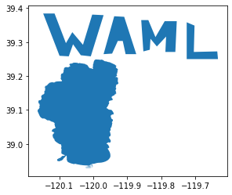

```python
waml.plot()
```

## Amazing.

Let's now find out the coordinate reference system of WAML.geojson

*Type:*  
*>>> waml.crs*

```python
waml.crs
```

```
{'init': 'epsg:4326'}
```

#### Good. The CRS is epsg 4326... AKA WGS84

*Type:*  
*>>> waml_lcc=waml.to_crs(epsg=2163)*

```python
waml_lcc = waml.to_crs(epsg=2163)
```

#### Now, let's view the difference

*Type:*  
*>>> waml_lcc.plot()*

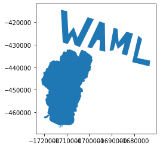

```python
waml_lcc.plot()
```

#### Okay, there are other methods to reset the crs, too. Let's change it to Transverse Mercator

*Type:*  
*>>> waml_tm = waml.to_crs({'proj':'tmerc'})*

```python
waml_tm = waml.to_crs({'proj':'tmerc'})
```

#### view the difference

*Type:*  
*>>> waml_tm.plot()*

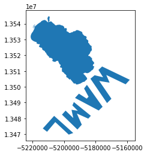

```python
waml_tm.plot()
```

#### Let's change it to NAD83 Nevada Central?

#### How do I know what code to use? Pro tip: https://spatialreference.org

*Type:*  
*>>> waml_Nev = waml.to_crs(epsg = 3422)*

```python
waml_Nev = waml.to_crs(epsg = 3422)
```

#### Plot it:

*Type:*  
*>>> waml_Nev.plot()*

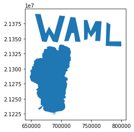

```python
waml_Nev.plot()
```

#### Okay, so far we've basically been creating all this stuff using RAM. Let's export the waml_Nev variable to a shapefile.

*Type:*  
*>>> waml_Nev.to_file('waml_Nev.shp')*

```python
waml_Nev.to_file('waml_Nev.shp')
```

#### Go check your data folder to confirm.

## But shapefiles are lame and boring. Let's make a geojson file instead:

*Type:*  
*>>> waml_Nev.to_file('waml_Nev.geojson', driver='GeoJSON')*

```python
waml_Nev.to_file('waml_Nev.geojson', driver = 'GeoJSON')
```